# SingleCellAnalysisWorkshop_2023 Book1

# Single Cell Analysis in R 2023 Notebook 1

This workbook presents the first part of a basic work flow for scRNAseq analysis 1. Loading data 2. Quality Control 2.1 Cell filtering 2.2 Doublet assessment 3. Normalization 4. Feature selection 5. Dimensionality reduction

# Analysis workflow

Load your required libraries. You need to have these libraries installed.

```r
Sys.time()
```

```
## [1] "2023-04-17 08:59:27 EDT"
```

```r
library(Seurat)
library(tidyverse)
library(DoubletFinder)
```

Load the data: Starting with the adolescent data.

```r
# load data

# insert the pathway to the location of the data
setwd("C:/Users/Home/Documents/GitHub/SingleCell_Workshop/")

adolescent_data <- Read10X("data/Adolescent_14_YO_raw_feature_bc_matrix/",
                      strip.suffix = TRUE )

#Look at the dimensions of the matrix
dim(adolescent_data)
```

```
## [1]   33538 6794880
```

```r
#Look at a small part of the data
adolescent_data[1:5, 1:5]
```

```
## 5 x 5 sparse Matrix of class "dgCMatrix"
##             AAACCCAAGAAACACT AAACCCAAGAAACCAT AAACCCAAGAAACCCA AAACCCAAGAAACCCG
## MIR1302-2HG                .                .                .                .
## FAM138A                    .                .                .                .
## OR4F5                      .                .                .                .
## AL627309.1                 .                .                .                .
## AL627309.3                 .                .                .                .
##             AAACCCAAGAAACCTG
## MIR1302-2HG                .
## FAM138A                    .
## OR4F5                      .
## AL627309.1                 .
## AL627309.3                 .
```

```r
#Look at the distribution of the number of UMIs per cell
colSums(adolescent_data) %>% summary
```

```
##      Min.   1st Qu.    Median      Mean   3rd Qu.      Max.
##     0.000     0.000     0.000     4.177     0.000 28647.000
```

```r
#Look at the distribution of the number of genes per cell
colSums(adolescent_data > 0) %>% summary
```

```
##     Min.  1st Qu.   Median     Mean  3rd Qu.     Max.
##    0.000    0.000    0.000    2.074    0.000 6315.000
```

Remove barcodes with too few genes that could be empty droplets

```r
#Remove barcodes with less than 200 genes detected (you can select a different value here)
#You could use something more refined here, like EmptyDrops
adolescent_data <- adolescent_data[, colSums(adolescent_data > 0)> 200]
dim(adolescent_data)
```

```
## [1] 33538  7371
```

Now we have gone from 6794880 barcodes to 7371 barcodes. These barcodes now represent cells.

Filter genes and create a Seurat object

```r
#We might not want to include genes that occur in few cells are no cells.  Here we will filter out genes/transcripts that are in less than 3 cells.

#Make a Seurat object
#Removing any genes detected in less than 3 cells
adolescent_data_seurat <- CreateSeuratObject(adolescent_data, project = "Adolescent", min.cells = 3)
# look at the object dimensions
adolescent_data_seurat
```

```
## An object of class Seurat
## 19866 features across 7371 samples within 1 assay
## Active assay: RNA (19866 features, 0 variable features)
```

We have now gone from 33538 RNA transcripts/genes to 19866 genes.

Now we will look at some metadata in the seurat object

```r
#Look at some metadata
adolescent_data_seurat@meta.data %>% names
```

```
## [1] "orig.ident"   "nCount_RNA"   "nFeature_RNA"
```

```r
# there are the meta data we currently have in our seurat object
```

Data distribution

```r
# look at the distribution of total counts of RNA across cells
adolescent_data_seurat$nCount_RNA %>% summary
```

```
##    Min. 1st Qu.  Median    Mean 3rd Qu.    Max.
##     228    1866    3080    3459    4486   28645
```

```r
# look at the distribution of unique RNA transcripts across cells

adolescent_data_seurat$nFeature_RNA %>% summary
```

```
##    Min. 1st Qu.  Median    Mean 3rd Qu.    Max.
##     201     999    1361    1558    2132    6315
```

Visualize the distributions

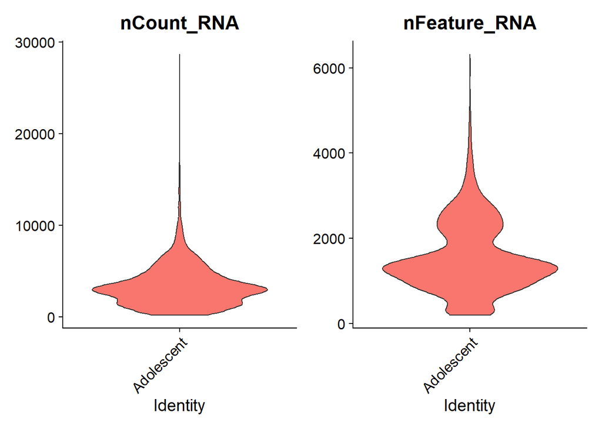

```r
VlnPlot(adolescent_data_seurat, features = c("nCount_RNA","nFeature_RNA"), pt.size = 0)
```

Repeat all these steps with the adult data.

```r
#Repeat above steps for the adult dataset, use a minimum genes per cell barcode cutoff of 200
#With real data you would use the same cutoff across samples
#You would decide the cutoff based on what works best across your samples.
#Can be left as an exercise i.e. no code provided until after the workshop or code provided in a different file

adult_data <- Read10X(data.dir = "data/Adult_41_YO_raw_feature_bc_matrix/",
                    strip.suffix = TRUE)
dim(adult_data)
```

```
## [1]   33538 6794880
```

```r
adult_data[1:5, 1:5]
```

```
## 5 x 5 sparse Matrix of class "dgCMatrix"
##             AAACCCAAGAAACACT AAACCCAAGAAACCAT AAACCCAAGAAACCCA AAACCCAAGAAACCCG
## MIR1302-2HG                .                .                .                .
## FAM138A                    .                .                .                .
## OR4F5                      .                .                .                .
## AL627309.1                 .                .                .                .
## AL627309.3                 .                .                .                .
##             AAACCCAAGAAACCTG
## MIR1302-2HG                .
## FAM138A                    .
## OR4F5                      .
## AL627309.1                 .
## AL627309.3                 .
```

```r
colSums(adult_data) %>% summary
```

```
##      Min.   1st Qu.    Median      Mean   3rd Qu.      Max.
##     0.000     0.000     0.000     1.538     0.000 22673.000
```

```r
colSums(adult_data > 0) %>% summary
```

```
##     Min.  1st Qu.   Median     Mean  3rd Qu.     Max.
##    0.000    0.000    0.000    0.798    0.000 5844.000
```

```r
adult_data <- adult_data[, colSums(adult_data > 0)> 200]
dim(adult_data)
```

```
## [1] 33538  2201
```

```r
adult_data_seurat <- CreateSeuratObject(adult_data, project = "Adult", min.cells = 3)
adult_data_seurat
```

```
## An object of class Seurat
## 17269 features across 2201 samples within 1 assay
## Active assay: RNA (17269 features, 0 variable features)
```

```r
adult_data_seurat@meta.data %>% names
```

```
## [1] "orig.ident"   "nCount_RNA"   "nFeature_RNA"
```

```r
adult_data_seurat$nCount_RNA %>% summary
```

```
##    Min. 1st Qu.  Median    Mean 3rd Qu.    Max.
##     226    1213    3235    3711    5444   22652
```

Now we want to add some sample meta data

```r
#Make a tibble with the age info
colnames(adolescent_data_seurat) %>% head
```

```
## [1] "AAACCCAAGATCGCTT" "AAACCCAAGGTTCAGG" "AAACCCACATGATCTG" "AAACCCAGTAACTAAG"
## [5] "AAACCCAGTCAACACT" "AAACCCAGTCCAATCA"
```

```r
adolescent_sample_metadata <- tibble(Cell_barcodes = colnames(adolescent_data_seurat),
                                age = rep(14, dim(adolescent_data_seurat)[2]))
head(adolescent_sample_metadata)
```

| Cell_barcodes | age |
| --- | --- |
| AAACCCAAGATCGCTT | 14 |
| AAACCCAAGGTTCAGG | 14 |
| AAACCCACATGATCTG | 14 |
| AAACCCAGTAACTAAG | 14 |
| AAACCCAGTCAACACT | 14 |
| AAACCCAGTCCAATCA | 14 |

```r
# this sample is from one brain and the age is 14 years so we will add that data for all the cells
```

The cells have previously been annotated - we will add in those annotations

```r
# input file path

input_file <- paste("data/HA799_14YO_metadata.csv",sep="")

#Read in metadata file with original cluster info
adolescent_sample_clusters <- read_csv(file = input_file)
```

```
## ──────────────────────────────────────────────────────── Delimiter: "," chr
## (3): ...1, orig.ident, Cell_type dbl (5): nCount_RNA, nFeature_RNA, percent.mt,
## RNA_snn_res.0.6, seurat_clusters
```

```r
head(adolescent_sample_clusters)
```

| ...1 | orig.ident | nCount_RNA | nFeature_RNA | percent.mt | RNA_snn_res.0.6 | seurat_clusters | Cell_type |
| --- | --- | --- | --- | --- | --- | --- | --- |
| AAACCCAAGATCGCTT | HA799 | 3212 | 1556 | 6.195517 | 0 | 0 | Microglia |
| AAACGAAAGCAACTCT | HA799 | 4239 | 1643 | 9.294645 | 0 | 0 | Microglia |
| AAACGAACAAATCCCA | HA799 | 3108 | 1128 | 9.073359 | 0 | 0 | Microglia |
| AAACGAAGTGCAATAA | HA799 | 3524 | 1668 | 5.419977 | 0 | 0 | Microglia |
| AAACGAATCTTGGGCG | HA799 | 2437 | 1505 | 6.811654 | 0 | 0 | Microglia |
| AAACGCTAGGTGATAT | HA799 | 4309 | 1651 | 6.799722 | 0 | 0 | Microglia |

Select the columns we need

```r
adolescent_sample_clusters <- adolescent_sample_clusters %>% select(-c(2:7))

colnames(adolescent_sample_clusters) <- c("Cell_barcodes","Original_clusterID")

head(adolescent_sample_clusters)
```

| Cell_barcodes | Original_clusterID |
| --- | --- |
| AAACCCAAGATCGCTT | Microglia |
| AAACGAAAGCAACTCT | Microglia |
| AAACGAACAAATCCCA | Microglia |
| AAACGAAGTGCAATAA | Microglia |
| AAACGAATCTTGGGCG | Microglia |
| AAACGCTAGGTGATAT | Microglia |

Now we will combine the two meta data ojbects and add the meta data into the Seurat object

```r
#Combine the age and original cluster metadata into a single object
#Note that not all the cells we have retained were present in the original analysis, we will keep all our called cells
adolescent_sample_metadata %>% left_join(adolescent_sample_clusters, by = "Cell_barcodes") %>%
  column_to_rownames("Cell_barcodes") %>% as.data.frame -> adolescent_sample_metadata
adolescent_sample_metadata %>% head
```

|  | age | Original_clusterID |
| --- | --- | --- |
| AAACCCAAGATCGCTT | 14 | Microglia |
| AAACCCAAGGTTCAGG | 14 | Microglia |
| AAACCCACATGATCTG | 14 | Microglia |
| AAACCCAGTAACTAAG | 14 | NA |
| AAACCCAGTCAACACT | 14 | NA |
| AAACCCAGTCCAATCA | 14 | Microglia |

```r
#Here we add the metadata to our Seurat object
adolescent_data_seurat <- AddMetaData(adolescent_data_seurat, metadata = adolescent_sample_metadata)
adolescent_data_seurat@meta.data %>% head
```

|  | orig.ident | nCount_RNA | nFeature_RNA | age | Original_clusterID |
| --- | --- | --- | --- | --- | --- |
| AAACCCAAGATCGCTT | Adolescent | 3212 | 1556 | 14 | Microglia |
| AAACCCAAGGTTCAGG | Adolescent | 4807 | 1808 | 14 | Microglia |
| AAACCCACATGATCTG | Adolescent | 1945 | 1015 | 14 | Microglia |
| AAACCCAGTAACTAAG | Adolescent | 7173 | 2735 | 14 | NA |
| AAACCCAGTCAACACT | Adolescent | 312 | 205 | 14 | NA |
| AAACCCAGTCCAATCA | Adolescent | 3350 | 1539 | 14 | Microglia |

```r
#Remove the original matrix, and other unnecessary objects to clean up space
rm(adolescent_data, adolescent_sample_metadata, adolescent_sample_clusters)
```

Repeat adding meta data for the adult object

```r
#Repeat the process of adding metadata for the adult sample
input_file <- paste("data/HA801_41YO_metadata.csv",sep="")

adult_sample_metadata <- tibble(CellName = colnames(adult_data_seurat),
                                age = rep(41, dim(adult_data_seurat)[2]))
adult_sample_clusters <- read_csv(file = input_file) %>% select(-c(2:7))
```

```
## ──────────────────────────────────────────────────────── Delimiter: "," chr
## (3): ...1, orig.ident, ...8 dbl (5): nCount_RNA, nFeature_RNA, percent.mt,
## RNA_snn_res.0.6, seurat_clusters
```

```r
colnames(adult_sample_clusters) <- c("CellName", "OriginalCluster")
adult_sample_metadata %>% full_join(adult_sample_clusters, by = "CellName") %>%
  column_to_rownames("CellName") %>% as.data.frame -> adult_sample_metadata
adult_data_seurat <- AddMetaData(adult_data_seurat, metadata = adult_sample_metadata)
adult_data_seurat@meta.data %>% head
```

|  | orig.ident | nCount_RNA | nFeature_RNA | age | OriginalCluster |
| --- | --- | --- | --- | --- | --- |
| AAACCCACACGAGGAT | Adult | 549 | 300 | 41 | NA |
| AAACCCATCCTGGGTG | Adult | 2544 | 1413 | 41 | NA |
| AAACGAAAGATGCAGC | Adult | 535 | 299 | 41 | NA |
| AAACGAAGTCGTGGTC | Adult | 4095 | 1796 | 41 | NA |
| AAACGAATCGAGTTGT | Adult | 7012 | 3110 | 41 | NA |
| AAACGAATCTTGCGCT | Adult | 4238 | 2180 | 41 | Oligodendrocyte |

```r
# clean up extra files
rm(adult_data, adult_sample_clusters, adult_sample_metadata)
```

Filter out unwanted cells

```r
# Example cell filtering based on mitochondrial count percentage and number of UMIs ----------

#Calculate the percentage of mitochondrially encoded mitochondrial genes
adolescent_data_seurat <- PercentageFeatureSet(adolescent_data_seurat, pattern = "^MT-", col.name = "percent.MT")
adolescent_data_seurat$percent.MT %>% summary
```

```
##    Min. 1st Qu.  Median    Mean 3rd Qu.    Max.
##   0.000   4.118   6.381   7.654   9.558  63.859
```

Visualize the mitochondria

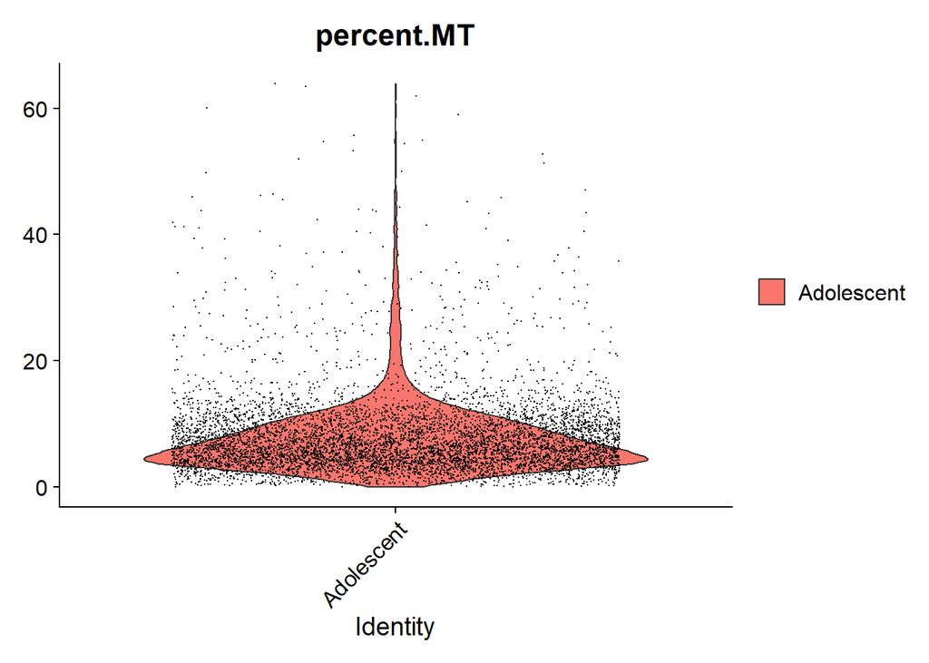

```r
VlnPlot(adolescent_data_seurat, features = "percent.MT", pt.size = 0.001)
```

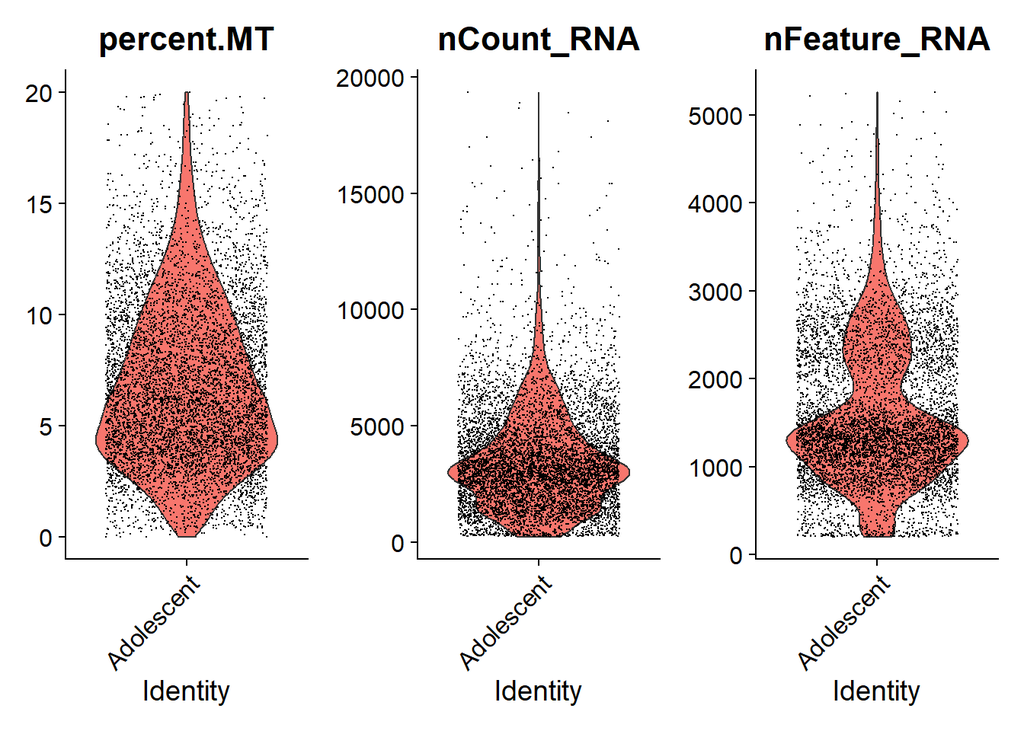

```r
#Remove any cells with more than 20% mitochondrial counts
adolescent_data_seurat <- subset(adolescent_data_seurat, percent.MT < 20)

#Remove cells with very high UMI counts, which may be possible multiplets
adolescent_data_seurat <- subset(adolescent_data_seurat, nCount_RNA < 20000)

# see the results
VlnPlot(adolescent_data_seurat, features = c("percent.MT", "nCount_RNA", "nFeature_RNA"), pt.size = 0.001)
```

Repeat filtering for the adult sample

```r
#Repeat filtering based on mitochondrial genes and number of UMIs for the adult sample
#Use the same criteria as we used for the adolescent sample
#Can be left as an exercise
adult_data_seurat <- PercentageFeatureSet(adult_data_seurat, pattern = "^MT-", col.name = "percent.MT")
adult_data_seurat$percent.MT %>% summary
```

```
##    Min. 1st Qu.  Median    Mean 3rd Qu.    Max.
##   0.000   4.232   7.094  10.299  12.292  82.212
```

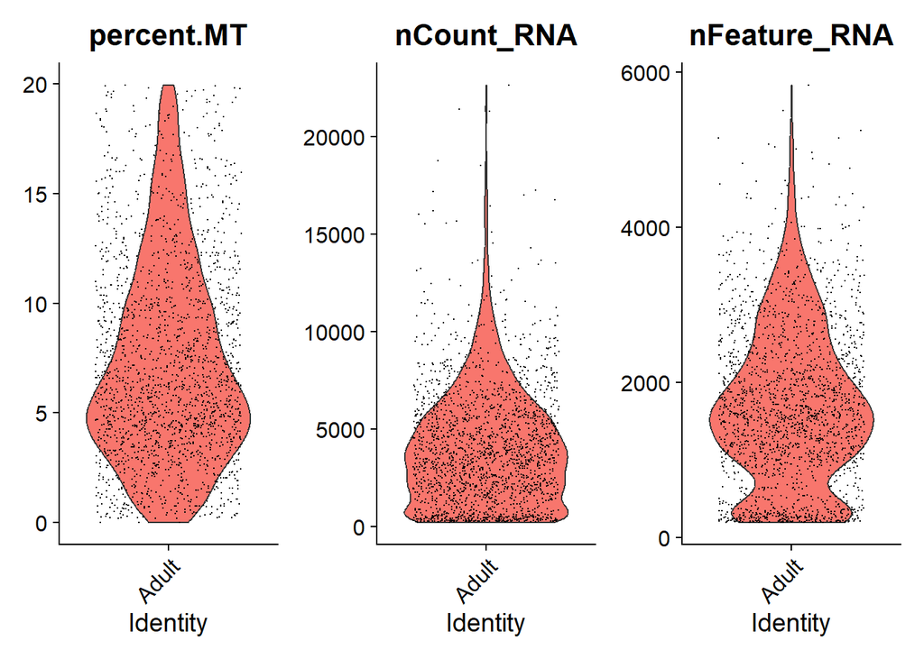

```r
adult_data_seurat <- subset(adult_data_seurat, percent.MT < 20)
VlnPlot(adult_data_seurat, features = c("percent.MT", "nCount_RNA", "nFeature_RNA"))
```

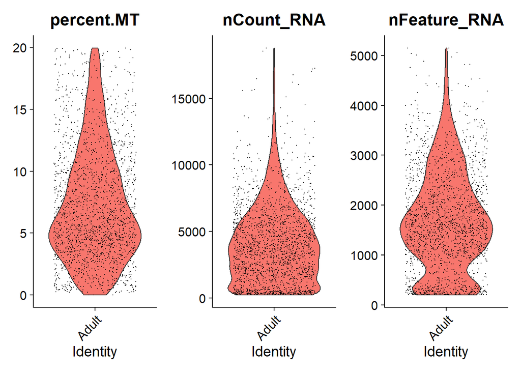

```r
adult_data_seurat <- subset(adult_data_seurat, nCount_RNA < 20000)
VlnPlot(adult_data_seurat, features = c("percent.MT", "nCount_RNA", "nFeature_RNA"))
```

Cell cycle scoring (optional)

```r
adolescent_data_seurat <- CellCycleScoring(adolescent_data_seurat, g2m.features = cc.genes$g2m.genes, s.features = cc.genes$s.genes)
```

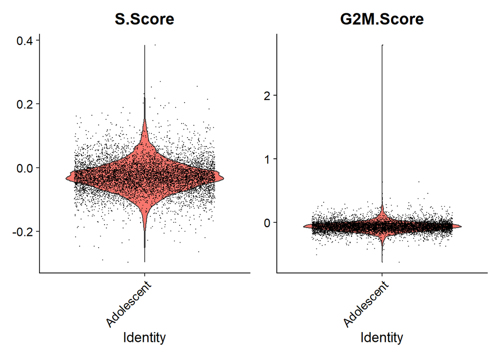

```r
VlnPlot(adolescent_data_seurat, features = c("S.Score", "G2M.Score"))
```

```r
adult_data_seurat <- CellCycleScoring(adult_data_seurat, g2m.features = cc.genes$g2m.genes, s.features = cc.genes$s.genes)
```

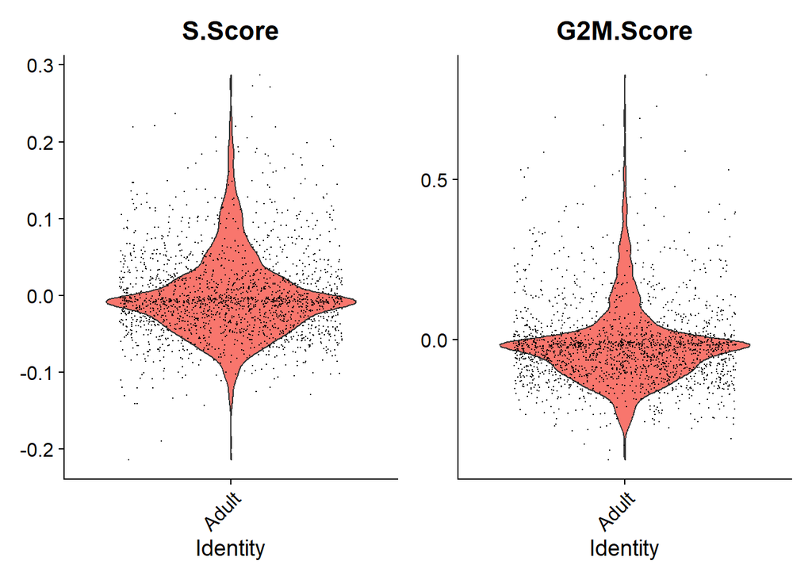

```r
VlnPlot(adult_data_seurat, features = c("S.Score", "G2M.Score"))
```

Data normalization

```r
# Normalize data (log normalization) and select genes with variable expression across cells --------------------------------------

adolescent_data_seurat <- NormalizeData(adolescent_data_seurat, normalization.method = "LogNormalize", scale.factor = 10000)

#Check out the effect of normalization
GetAssayData(adolescent_data_seurat, assay = "RNA", slot = "data") %>% expm1 %>% colSums %>% head
```

```
## AAACCCAAGATCGCTT AAACCCAAGGTTCAGG AAACCCACATGATCTG AAACCCAGTAACTAAG
##            10000            10000            10000            10000
## AAACCCAGTCAACACT AAACCCAGTCCAATCA
##            10000            10000
```

```r
GetAssayData(adolescent_data_seurat, assay = "RNA", slot = "counts") %>% colSums %>% head
```

```
## AAACCCAAGATCGCTT AAACCCAAGGTTCAGG AAACCCACATGATCTG AAACCCAGTAACTAAG
##             3212             4807             1945             7173
## AAACCCAGTCAACACT AAACCCAGTCCAATCA
##              312             3350
```

Finding Variable feature with two different methods

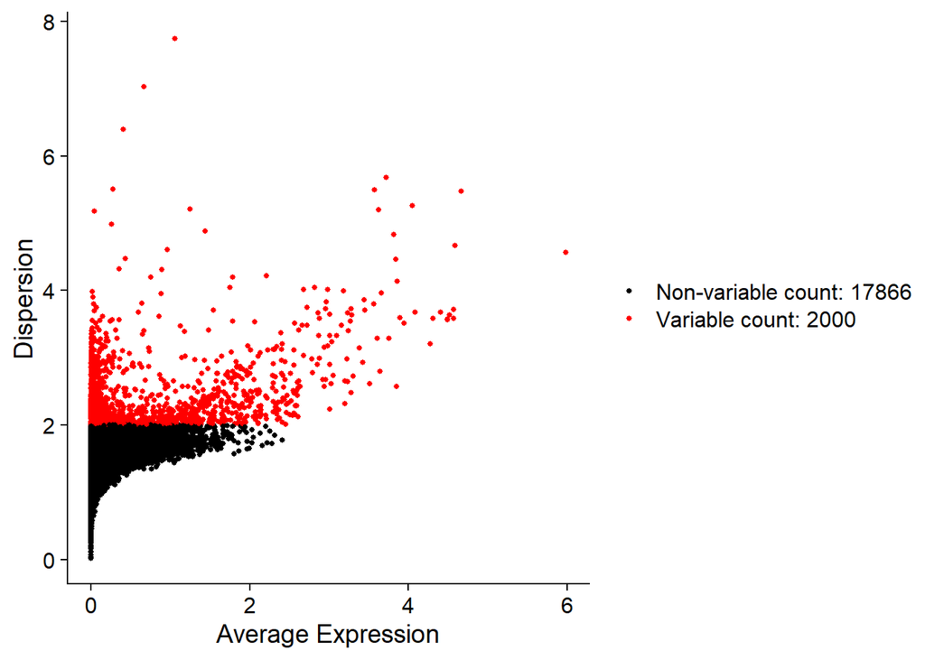

```r
# Dispersion
#Find and plot variable features (in our case genes) with dispersion based method
adolescent_data_seurat <- FindVariableFeatures(adolescent_data_seurat, selection.method = "disp", nfeatures = 2000)
VariableFeaturePlot(adolescent_data_seurat)
```

```r
disp_var  <- VariableFeatures(adolescent_data_seurat)
```

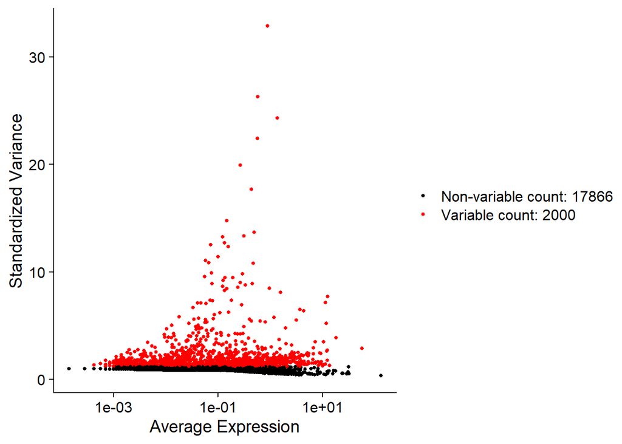

```r
# VST
#Find and plot variable features (in our case genes) with vst based method
adolescent_data_seurat <- FindVariableFeatures(adolescent_data_seurat, selection.method = "vst", nfeatures = 2000)

VariableFeaturePlot(adolescent_data_seurat)
```

Compare both

```r
#Compare the two methods, look at some of the variable genes
intersect(disp_var, VariableFeatures(adolescent_data_seurat)) %>% length
```

```
## [1] 745
```

```r
VariableFeatures(adolescent_data_seurat) %>% head(n = 20)
```

```
##  [1] "SPARCL1" "SLC1A2"  "CLU"     "CPE"     "GPR17"   "BCAN"    "LYZ"
##  [8] "SCRG1"   "HSPA6"   "GJA1"    "GPNMB"   "S100A9"  "ATP1B2"  "GJB6"
## [15] "S100A8"  "WIF1"    "CCL2"    "ETNPPL"  "TUBB2B"  "AREG"
```

Repeat for the adult sample

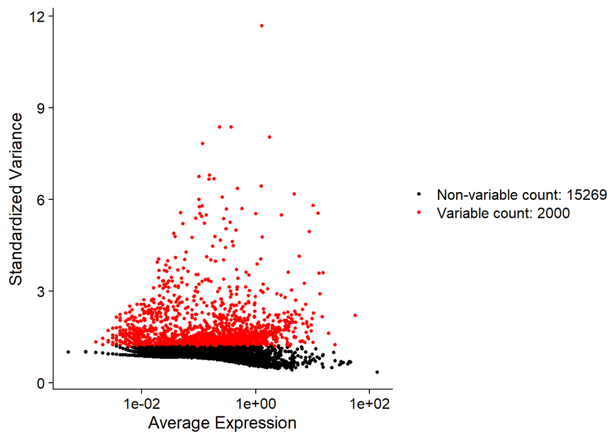

```r
#Repeat normalization and variable feature selection for adult sample
#Use method vst and 2000 variable features
#Can be left as an exercise

adult_data_seurat <- NormalizeData(adult_data_seurat, normalization.method = "LogNormalize", scale.factor = 10000)
adult_data_seurat <- FindVariableFeatures(adult_data_seurat, selection.method = "vst", nfeatures = 2000)
VariableFeaturePlot(adult_data_seurat)
```

```r
VariableFeatures(adult_data_seurat) %>% head(n = 20)
```

```
##  [1] "HSPA6"    "GPNMB"    "VIM"      "CXCL8"    "TUBB2B"   "CCL5"
##  [7] "CXCL2"    "IFIT3"    "SLC1A2"   "IRF1"     "SERPINE1" "MT2A"
## [13] "G0S2"     "S100A8"   "CCL4"     "FAM43A"   "S100A4"   "IL1A"
## [19] "SOX4"     "VCAN"
```

Dimensionality reduction PCA and UMAP

```r
#Scaling is recommended before PCA, as otherwise highly expressed genes will have a disproportionate effect
adolescent_data_seurat <- ScaleData(adolescent_data_seurat, vars.to.regress = "percent.MT")
adolescent_data_seurat@assays$RNA@scale.data %>% dim
```

```
## [1] 2000 7101
```

```r
#Linear dimensionality reduction
#Choosing the number of PCs can depend on how many cells you have
adolescent_data_seurat <- RunPCA(adolescent_data_seurat, assay = "RNA", npcs = 30)
```

```
## PC_ 1
## Positive:  APLP1, PCDH9, EDIL3, TF, PPP1R14A, CNP, GPM6B, MAG, MARCKSL1, TUBB4A
##     ENPP2, AMER2, CLDN11, SCD, SLAIN1, PTGDS, ERMN, CNTN2, MOG, CD9
##     MAL, GPRC5B, HSPA2, TTLL7, GPR37, CRYAB, PLP1, PLLP, SEPT4, PRR18
## Negative:  CEBPD, CD74, CEBPB, SAT1, RGS1, SRGN, KLF6, APOE, CST3, KLF2
##     HLA-DRA, CH25H, DUSP1, CD83, HLA-DRB1, JUN, CCL3, HLA-DPA1, ID2, P2RY13
##     ZFP36L1, MIS18BP1, SPRY1, PDK4, EGR3, GPR183, CLEC7A, AC020916.1, SAMSN1, GRASP
## PC_ 2
## Positive:  GPM6A, OLFM2, PTPRZ1, NRXN1, BCAN, SERPINE2, SPARCL1, SCG3, CPE, ATP1A2
##     NKAIN4, SLC1A2, CLDN10, TMEM100, HIF3A, FABP7, CHL1, ATP1B2, TUBB2B, TNR
##     NRCAM, FGFR3, EDNRB, C1orf61, ACSL6, TIMP3, SCRG1, LUZP2, ENHO, MT1M
## Negative:  SPP1, RNASE1, DUSP1, EVI2A, TMEM144, MAG, ERMN, ENPP2, CARNS1, ANLN
##     FOSB, NKX6-2, OPALIN, MOBP, HHIP, CLDN11, PTMA, RGS1, PIP4K2A, NECAB1
##     CNDP1, HSP90AA1, RAPGEF5, CD74, FAM107B, CNTN2, GPR37, SEPT4, SRGN, GAS7
## PC_ 3
## Positive:  TNR, PDGFRA, MEG3, VCAN, C1QL1, COL9A1, LY6H, CA10, GPR17, PCDH15
##     FGF12, MEGF11, ATCAY, MMP16, RASD1, AFAP1L2, FXYD6, LUZP2, GPNMB, SOX6
##     ASCL1, PHLDA1, ASIC4, NXPH1, MYT1, B3GNT7, SEMA5A, THY1, KCNIP4, CSPG4
## Negative:  GJB6, GJA1, AQP4, ETNPPL, ID4, MGST1, SLCO1C1, MGAT4C, WIF1, F3
##     SDC4, SLC4A4, CXCL14, AGT, PPP1R1B, ADGRV1, GABRA2, FXYD1, SLC25A18, RORB
##     SLC39A12, FGFR3, RANBP3L, SDC2, PDGFRB, ATP1B2, ANGPTL4, IGFBP7, BMPR1B, EFEMP1
## PC_ 4
## Positive:  HIST1H2BG, AL034397.3, PLCG2, AC243960.1, MIR503HG, HSPA1A, HSPA1B, AL031777.3, PLEKHH2, AC110285.2
##     HSPB1, CPB2-AS1, ACSS1, FUT9, AC004158.1, GRIA2, CST3, CCP110, ITM2A, GOLGA8B
##     PLP1, ADGRL3, THBS2, PPP1R9A, PLEKHA1, TMEM144, HIST1H2BH, MOSPD2, CADM2, KCNH8
## Negative:  EGR1, KDM6B, CD83, GRASP, EGR3, NR4A2, JUNB, FOSB, EGR2, ZFP36
##     NR4A1, BTG2, NR4A3, DUSP1, GADD45B, NFKBID, ID2, CCL3L1, MAP3K8, CCL3
##     TRIB1, SRGN, HSPA8, PLAUR, CDKN1A, ATF3, IER2, SYAP1, NEDD9, KLF4
## PC_ 5
## Positive:  PLAUR, BCL2A1, NR4A3, CCL4L2, CCL4, TRIB1, ITGAX, CCL3L1, TNFAIP8L3, B3GNT5
##     NEDD9, NFKBID, MAP3K8, ABL2, EIF4E, DUSP4, PTGER4, CD69, GRASP, VMP1
##     CCL2, ZNF331, BASP1, IL1B, IL1A, GPR183, DUSP5, KDM6B, OSM, C5AR1
## Negative:  DNAJB1, IER2, HSPA1A, HSPA1B, JUN, EGR1, IRF1, FOSB, JUNB, BTG2
##     HSP90AA1, SOCS3, ID1, HSPH1, EFNA1, DUSP1, NFKBIZ, ZFP36, AC116366.1, TUBB4B
##     LDLR, DLL1, MYADM, HSPE1, TNFSF9, MAFF, IRF9, HSPD1, CFAP20, SRSF7
```

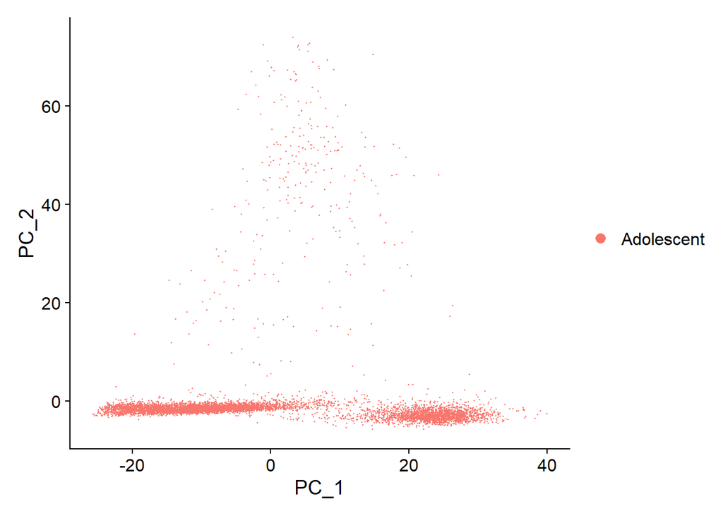

```r
#PCAPlot(adolescent_data_seurat, group.by = "Original_clusterID")
# this a confusing because we won't normally have this

PCAPlot(adolescent_data_seurat)
```

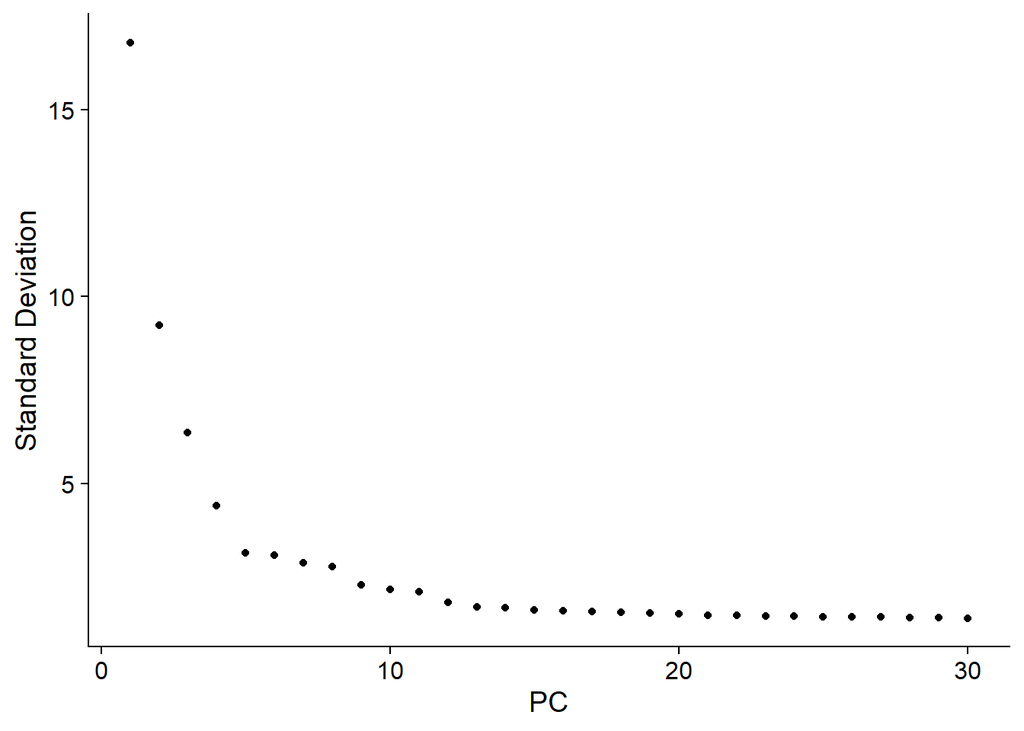

```r
#Assess how many PCs capture most of the information in the data
ElbowPlot(adolescent_data_seurat, ndims = 30)
```

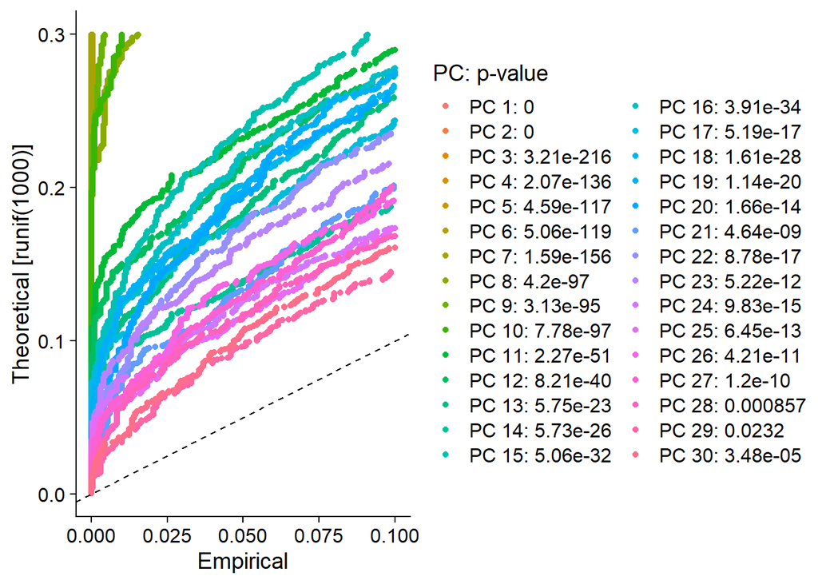

```r
# Jackstraw

#Assess how many PCs capture most of the information in the data
adolescent_data_seurat <-JackStraw(adolescent_data_seurat, reduction = "pca",
  dims = 30)
adolescent_data_seurat <- ScoreJackStraw(adolescent_data_seurat, reduction = "pca", dims = 1:30)
JackStrawPlot(adolescent_data_seurat, dims = 1:30)
```

Non-linear dimensional reduction using UMAP

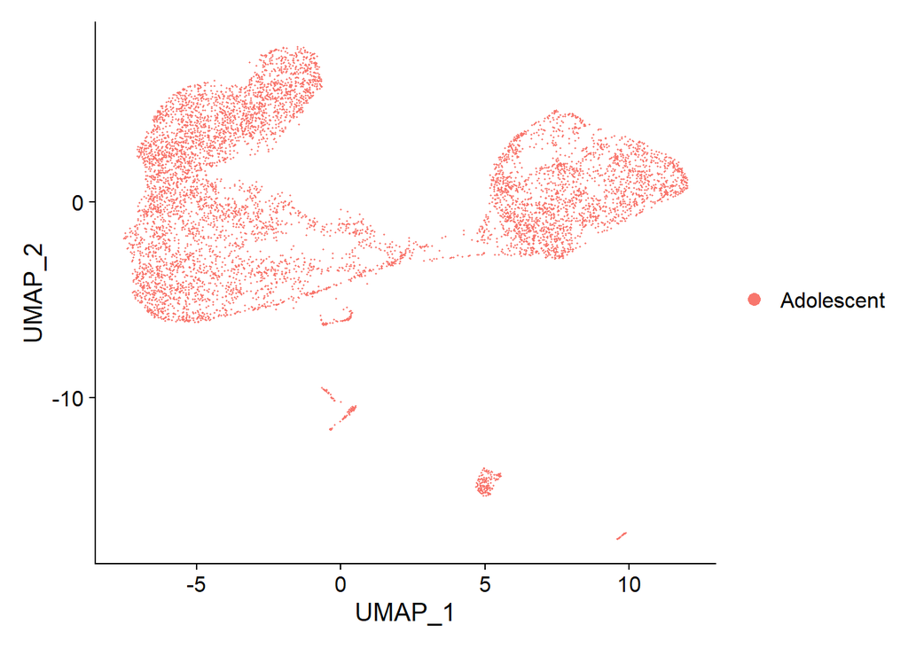

```r
#Non-linear dimensionality reduction
#Choosing how many PCs to input can depend on the elbow plot and on the number of cells
#There are many parameters that can e tweaked and optimized in a UMAP plot
#You can see some demos here: https://pair-code.github.io/understanding-umap/
adolescent_data_seurat <- RunUMAP(adolescent_data_seurat, dims = 1:10)
UMAPPlot(adolescent_data_seurat)
```

Repeat dimensional reduction with the adult sample

```r
#Repeat dimensional reduction for adult sample, use 10 PCs for
adult_data_seurat <- ScaleData(adult_data_seurat, vars.to.regress = "percent.MT")
adult_data_seurat <- RunPCA(adult_data_seurat, assay = "RNA", npcs = 30)
```

```
## PC_ 1
## Positive:  HLA-DRA, HLA-DPA1, SRGN, SAT1, CST3, RGS1, CEBPB, APOE, S100A11, KLF6
##     CCL3, DUSP1, OLR1, KLF2, CH25H, MS4A7, CTSS, ZFP36L1, ID2, TREM2
##     CCL3L1, HLA-DPB1, CD83, AKAP13, SLC11A1, IER3, P2RY13, REL, CCL4L2, NFKBIA
## Negative:  APLP1, CNP, MAG, TF, EDIL3, GPM6B, CNTN2, GPR37, PLLP, ERMN
##     APOD, PCDH9, MOG, ENPP2, TUBB4A, GPRC5B, PPP1R14A, CLDN11, TTLL7, PTGDS
##     STMN4, PMP22, MARCKSL1, AMER2, NKX6-2, SPOCK3, UGT8, FEZ1, CRYAB, PLP1
## PC_ 2
## Positive:  SPARCL1, GPM6A, ATP1B2, CPE, TXNIP, SLC1A2, SERPINE2, AQP4, IL32, PLCG2
##     CD3E, ATP1A2, CD2, CLDN10, FXYD1, WIF1, CD3D, CD52, GJA1, MGST1
##     SCG3, DDAH1, TRAC, IGFBP7, TUBB2B, NKG7, F3, OLFM2, FGFR3, CD8A
## Negative:  KDM6B, GRASP, ZFP36, CD83, FOSB, JUNB, KLF4, FOS, PPP1R15A, KLF6
##     DUSP1, ID2, REL, NR4A1, NR4A2, MIDN, NLRP3, MYADM, PLAUR, GADD45B
##     SLC11A1, IER2, B3GNT5, KLF10, KLF2, TRIB1, C5AR1, CDKN1A, GPR183, MAP3K8
## PC_ 3
## Positive:  IL32, CD3E, CCL5, CD2, CD52, S100A4, CD3D, CD8A, TRAC, NKG7
##     GZMA, ANXA1, KLRD1, CD48, CTSW, TRBC2, LINC01871, TRBC1, TRGC2, TUBA4A
##     GZMK, CD96, S100A10, CST7, VIM, RUNX3, S100A6, GZMM, ETS1, BCL11B
## Negative:  SPP1, HLA-DRA, CST3, APOE, HLA-DPA1, TREM2, SAT1, CX3CR1, P2RY13, CH25H
##     FCGR1A, PDK4, CD14, APOC1, VSIG4, DHRS9, USP53, CCL3, MRC1, MS4A7
##     OLR1, OTUD1, GSTM3, CKB, AC011139.1, CYTL1, LYVE1, CTSS, SCIN, S100A11
## PC_ 4
## Positive:  SPP1, IL32, CD3E, CD2, CD8A, CCL5, TXNIP, NKG7, GZMA, CD3D
##     TRAC, OPALIN, PIP4K2A, KLRD1, CD52, TPPP, MOBP, SH3GL3, TRGC2, TRBC1
##     ZNF536, LINC01871, FAM107B, CTSW, TTLL7, CLMN, ARHGAP21, GZMK, TMEM144, CNDP1
## Negative:  GPM6A, SPARCL1, SLC1A2, ATP1B2, CPE, ATP1A2, PTPRZ1, AQP4, OLFM2, TUBB2B
##     SERPINE2, WIF1, FGFR3, GJA1, MGST1, CLDN10, F3, ALDOC, FXYD1, ID4
##     GJB6, SCG3, AGT, IGFBP7, ETNPPL, MLC1, SLC4A4, NRXN1, ENHO, BCAN
## PC_ 5
## Positive:  PLAUR, VEGFA, GRASP, MAP3K8, BASP1, NR4A3, SPHK1, BCL2A1, C5AR1, B3GNT5
##     BHLHE40, NFKB1, LCP2, SLC7A5, ADGRL3, NEDD9, S100A9, PNP, NLRP3, DUSP4
##     S100A8, RILPL2, AC245128.3, RAB20, BCAT1, DUSP5, IL1A, STX11, ITGAX, MAP2K3
## Negative:  DNAJB1, EGR1, HSPA1A, JUN, HSPA1B, IER2, IRF1, FOS, HSPH1, BTG2
##     IRF9, HSP90AA1, JUNB, AC007952.4, EFNA1, SOCS3, MAFF, TNFSF9, FOSB, DNAJA1
##     HSPD1, NFKBIZ, AC116366.1, BAG3, AC245014.3, BAMBI, GADD45B, FAM43A, ATF3, C11orf96
```

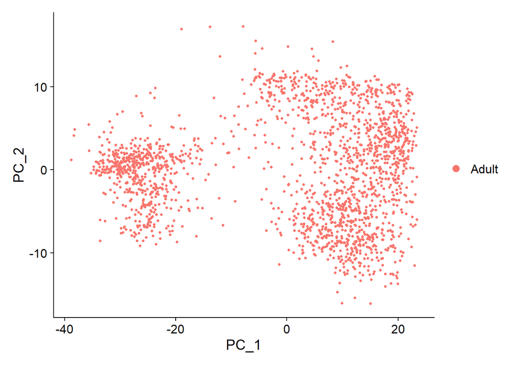

```r
PCAPlot(adult_data_seurat)
```

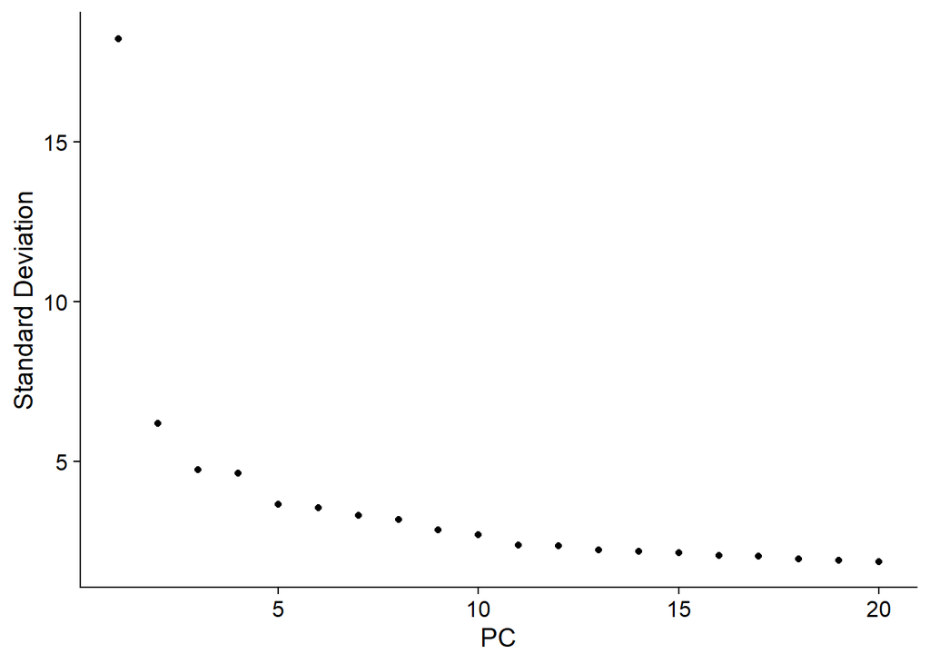

```r
ElbowPlot(adult_data_seurat)
```

```r
adult_data_seurat <- RunUMAP(adult_data_seurat, dims = 1:10)
```

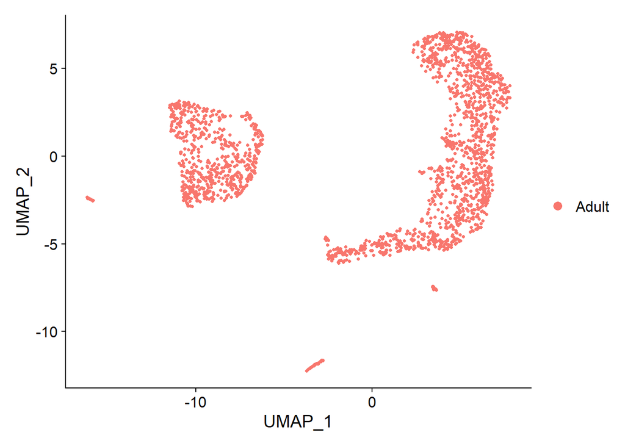

```r
UMAPPlot(adult_data_seurat)
```

Doublet identification

```r
# Assess possible doublets  -----------------------------------------------
#Using instructions here: https://github.com/chris-mcginnis-ucsf/

#First we have to find a pK which determines how big of a neighborhood will be examined for doublets
#This should be chosen for each library separately
#First we test a number of pN (proportion of generated artificial doublets) and pK
#We get different lists of probabilities of artifical nearest neighbors with these tested parameters
#Also keep in mind the results are not deterministic (every run will give slightly different results)
sweep.res.list_adolescent <- paramSweep_v3(adolescent_data_seurat, PCs = 1:15, sct = FALSE)
```

[output not shown]

[output not shown]

[output not shown]

[output not shown]

[output cut: 25 more lines]

[output not shown]

[output cut: 25 more lines]

[output not shown]

[output cut: 25 more lines]

[output not shown]

[output cut: 25 more lines]

[output not shown]

[output cut: 25 more lines]

[output not shown]

[output cut: 20 more lines]

```r
#We do not have the "ground truth" regarding doublets, such from from genotype data for pooled samples
#We sumamrize the performance of the range of pN=pK parameters we tested
sweep.stats_adolescent <- summarizeSweep(sweep.res.list_adolescent, GT = FALSE)
```

```
## Copyright M. P. Wand 1997-2009
```